# Untitled

## Imputing missing values

1.Calculate and report the total number of missing values in the dataset (i.e. the total number of rows with NAs)

```r
data3<-data[is.na(data$steps),]
NAS<-length(data3$steps)
```

The number of missing values is 2304

2.Strategy for filling in all of the missing values in the dataset by using the mean for that 5-minute interval. 3.Create a new dataset that is equal to the original dataset but with the missing data filled in.

```r
dataNONA<-data[!is.na(data$steps),]
dataNA<-left_join(select(data3, date, interval), select(data2, interval, mean_steps), by="interval")
colnames(dataNA)[3]<-"steps"
datafinal<-rbind(dataNONA, dataNA)
```

New data set

```r
head(datafinal)
```

```
    steps       date interval
289     0 2012-10-02        0
290     0 2012-10-02        5
291     0 2012-10-02       10
292     0 2012-10-02       15
293     0 2012-10-02       20
294     0 2012-10-02       25
```

4.Make a histogram of the total number of steps taken each day and Calculate and report the mean and median total number of steps taken per day. Do these values differ from the estimates from the first part of the assignment? What is the impact of imputing missing data on the estimates of the total daily number of steps?

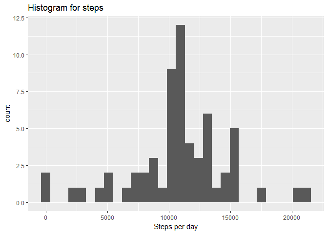

```r
datafinalsum<-datafinal%>%group_by(date)%>%summarise(sum_steps=sum(steps))
plot2<-ggplot(datafinalsum,aes(datafinalsum$sum_steps))+geom_histogram()+labs(title="Histogram for steps", x="Steps per day")
plot(plot2)
```

```r
mean_withoutNAS<-mean(datafinalsum$sum_steps)
median_withoutNAS<-median(datafinalsum$sum_steps)
```

The mean replacing NAS with the average of the interval is 1.076618910^{4}, and the median is 1.076618910^{4}. This values differ from the values without considering NAS, by imputting the mean of each interval to the NAS values the number of steps increased.

Are there differences in activity patterns between weekdays and weekends?

For this part the weekdays() function may be of some help here. Use the dataset with the filled-in missing values for this part. 1.Create a new factor variable in the dataset with two levels - “weekday” and “weekend” indicating whether a given date is a weekday or weekend day.

```r
datafinal$week<-weekdays(datafinal$date)
weekend<-c("sábado", "domingo")
datafinal$dayweek<-"weekdays"
datafinal[datafinal$week%in%weekend==TRUE,5]<-"weekend"
datafinal$dayweek<-as.factor(datafinal$dayweek)
```

2.Make a panel plot containing a time series plot (i.e. type = “l”) of the 5-minute interval (x-axis) and the average number of steps taken, averaged across all weekday days or weekend days (y-axis). See the README file in the GitHub repository to see an example of what this plot should look like using simulated data.

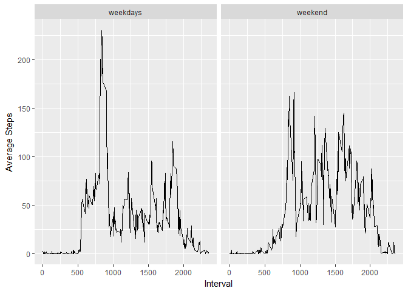

```r
datafinal2<-datafinal%>%group_by(interval,dayweek)%>%summarise(average_steps=mean(steps))
ggplot(datafinal2, aes(interval, average_steps))+geom_line()+facet_wrap(~ dayweek)+labs(x="Interval", y="Average Steps")
```